# Hierarchy Experiment: Statistical model

Bodo Winter (statistical analysis)

7/17/2019

## Introduction

This is the statistical analysis of our “hierarchy experiment”, a replication-extension of Schubert’s (2005) study which associates vertical positions with power. The present study includes the added dimension of gender.

This script takes the fitted Bayesian models and interprets them:

## Preprocessing

Load stuff:

```r
# Packages:

library(tidyverse)
library(brms)
library(ggrepel)

# ggplot2 theme:

source('timo_theme.R')
```

## Load the model:

Load the main model that is fitted by the file “bayes_model_estimation.R”:

```r
load('main_mdl.RData')
```

## Summarize the model:

```r
summary(main_mdl)
```

```
##  Family: gaussian
##   Links: mu = identity; sigma = identity
## Formula: LogRT ~ SubjGender + Task + Hierarchy + Gender + Hierarchy:Gender + SubjGender:Hierarchy + SubjGender:Gender + Hierarchy:Gender:SubjGender + Task:Hierarchy + Task:Gender + (1 + Hierarchy + Gender + Hierarchy:Gender | Subj) + (1 + Hierarchy + Gender + Hierarchy:Gender | PairName)
##    Data: power (Number of observations: 6801)
## Samples: 4 chains, each with iter = 4000; warmup = 2000; thin = 1;
##          total post-warmup samples = 8000
##
## Group-Level Effects:
## ~PairName (Number of levels: 32)
##                                    Estimate Est.Error l-95% CI u-95% CI
## sd(Intercept)                          0.08      0.01     0.06     0.10
## sd(Hierarchy1)                         0.03      0.01     0.00     0.05
## sd(Gender1)                            0.02      0.01     0.00     0.05
## sd(Hierarchy1:Gender1)                 0.04      0.02     0.00     0.09
## cor(Intercept,Hierarchy1)              0.45      0.29    -0.22     0.89
## cor(Intercept,Gender1)                 0.16      0.32    -0.51     0.76
## cor(Hierarchy1,Gender1)                0.11      0.40    -0.68     0.80
## cor(Intercept,Hierarchy1:Gender1)      0.12      0.36    -0.62     0.77
## cor(Hierarchy1,Hierarchy1:Gender1)     0.16      0.41    -0.69     0.84
## cor(Gender1,Hierarchy1:Gender1)       -0.08      0.42    -0.81     0.75
##                                    Eff.Sample Rhat
## sd(Intercept)                            1411 1.00
## sd(Hierarchy1)                           2198 1.00
## sd(Gender1)                              1849 1.00
## sd(Hierarchy1:Gender1)                   2003 1.00
## cor(Intercept,Hierarchy1)                5143 1.00
## cor(Intercept,Gender1)                   6261 1.00
## cor(Hierarchy1,Gender1)                  2874 1.00
## cor(Intercept,Hierarchy1:Gender1)        6468 1.00
## cor(Hierarchy1,Hierarchy1:Gender1)       3617 1.00
## cor(Gender1,Hierarchy1:Gender1)          4216 1.00
##
## ~Subj (Number of levels: 62)
##                                    Estimate Est.Error l-95% CI u-95% CI
## sd(Intercept)                          0.20      0.02     0.17     0.24
## sd(Hierarchy1)                         0.02      0.01     0.00     0.05
## sd(Gender1)                            0.02      0.01     0.00     0.04
## sd(Hierarchy1:Gender1)                 0.03      0.02     0.00     0.08
## cor(Intercept,Hierarchy1)             -0.20      0.31    -0.78     0.47
## cor(Intercept,Gender1)                -0.18      0.35    -0.78     0.60
```

[output cut: 34 more lines]

```
## Gender1                              4783 1.00
## Hierarchy1:Gender1                   5163 1.00
## SubjGender1:Hierarchy1               5236 1.00
## SubjGender1:Gender1                  5683 1.00
## Task1:Hierarchy1                     6948 1.00
## Task1:Gender1                        8328 1.00
## SubjGender1:Hierarchy1:Gender1       6015 1.00
##
## Family Specific Parameters:
##       Estimate Est.Error l-95% CI u-95% CI Eff.Sample Rhat
## sigma     0.31      0.00     0.30     0.31      10177 1.00
##
## Samples were drawn using sampling(NUTS). For each parameter, Eff.Sample
## is a crude measure of effective sample size, and Rhat is the potential
## scale reduction factor on split chains (at convergence, Rhat = 1).
```

Reminder of deviation coding scheme:

- subject gender: female = -0.5, male = +0.5
- task: powerless = -0.5, powerful = +0.5
- hierarchy: powerful + down = -0.5, powerful + up = +0.5
- gender: male + down = -0.5, male + up = +0.5

## Posterior probabilities:

Calculate the posterior probabilities of the respective effects. First, extract posteriors:

```r
p <- posterior_samples(main_mdl)

subjGender <- p$'b_SubjGender1'
task <- p$'b_Task1'
hierarchy <- p$'b_Hierarchy1'
gender <- p$'b_Gender1'
hierarchy_gender <- p$'b_Hierarchy1:Gender1'
subjGender_hierarchy <- p$'b_SubjGender1:Hierarchy1'
subjGender_Gender <- p$'b_SubjGender1:Gender1'
task_gender <- p$'b_Task1:Gender1'
task_hierarchy <- p$'b_Task1:Hierarchy1'
threeway <- p$'b_SubjGender1:Hierarchy1:Gender1'
```

Calculate posterior probabilities:

```r
# Subject effect:

sum(subjGender < 0) / nrow(p)
```

```
## [1] 0.709
```

```r
# Task effect:

sum(task < 0) / nrow(p)
```

```
## [1] 0.99975
```

```r
# Gender effect:

sum(gender < 0) / nrow(p)
```

```
## [1] 0.24475
```

```r
# Hierarchy effect:

sum(hierarchy < 0) / nrow(p)
```

```
## [1] 0.84075
```

```r
# Hierarchy * task interaction:

sum(task_hierarchy < 0) / nrow(p)
```

```
## [1] 0.1355
```

```r
# Task * gender interaction:

sum(task_gender < 0) / nrow(p)
```

```
## [1] 0.908875
```

```r
# Hierarchy * gender interaction:

sum(hierarchy_gender < 0) / nrow(p)
```

```
## [1] 1
```

```r
# Subject gender * hierarchy interaction:

sum(subjGender_hierarchy< 0) / nrow(p)
```

```
## [1] 0.634625
```

```r
# Subject gender * gender interaction:

sum(subjGender_Gender < 0) / nrow(p)
```

```
## [1] 0.522625
```

```r
# Threeway interaction:

sum(threeway < 0) / nrow(p)
```

```
## [1] 0.999875
```

## Plot the marginal effects:

Plot the marginal effects, task:

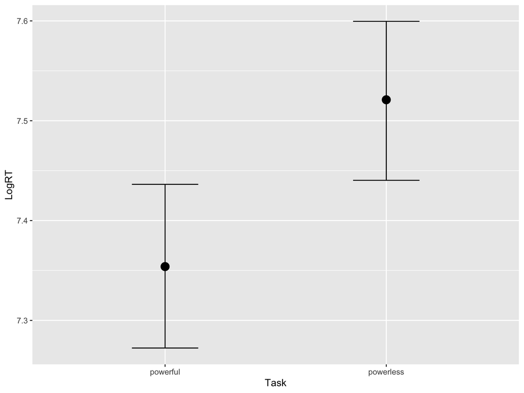

```r
marginal_effects(main_mdl, 'Task')
```

Plot the marginal effects, gender:

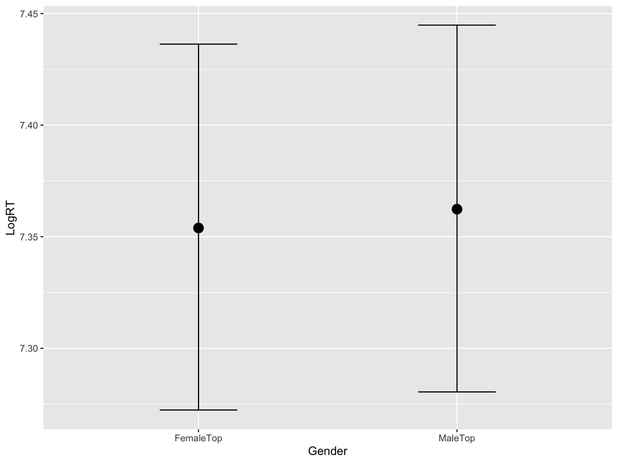

```r
marginal_effects(main_mdl, 'Gender')
```

Plot the marginal effects, hierarchy:

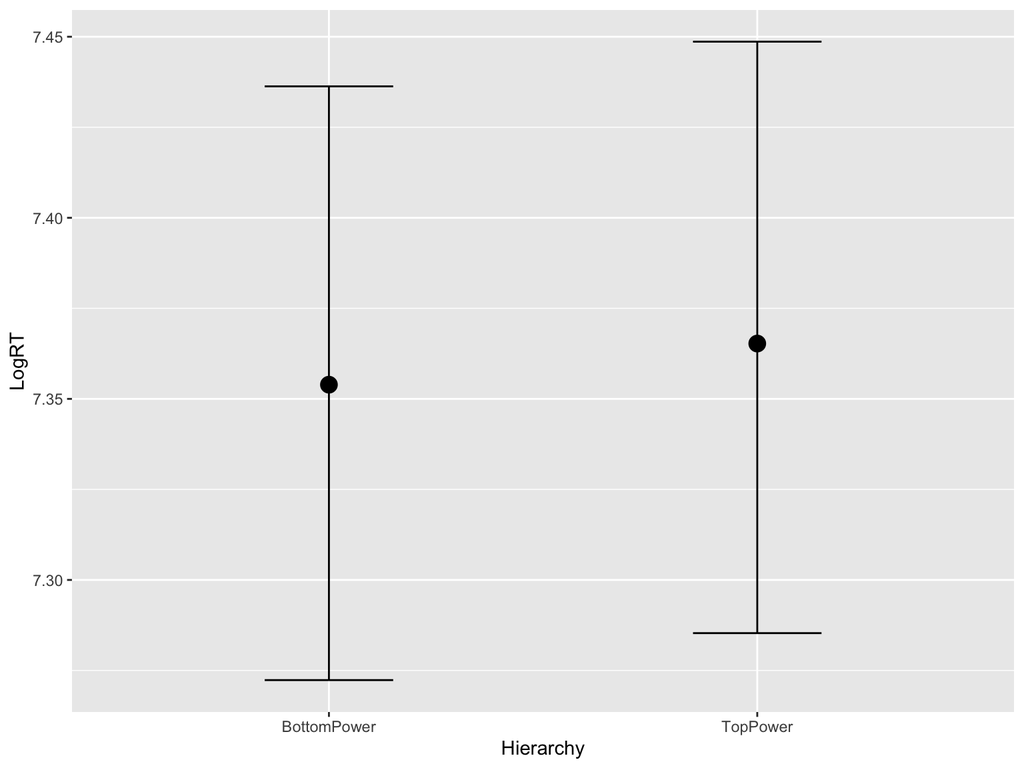

```r
marginal_effects(main_mdl, 'Hierarchy')
```

Hierarchy * gender interaction:

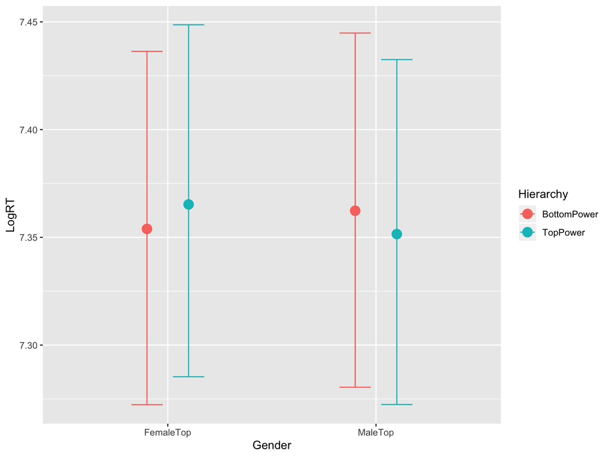

```r
marginal_effects(main_mdl, 'Gender:Hierarchy')
```

Task * hierearchy interaction:

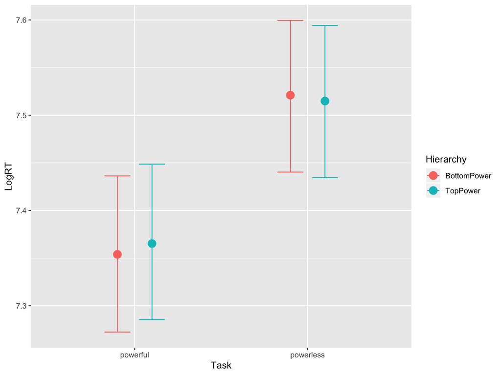

```r
task_hierarchy <- marginal_effects(main_mdl, 'Task:Hierarchy')
plot(task_hierarchy)
```

Three-way interaction:

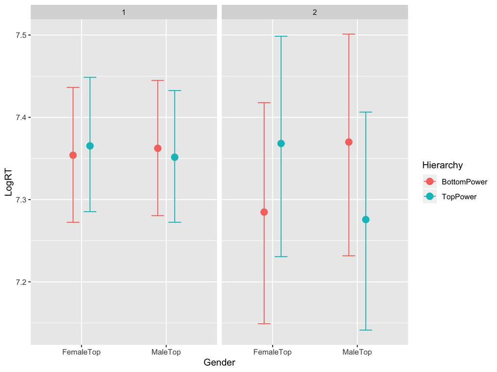

```r
conditions <- tibble(SubjGender = factor(c('female', 'male')))

interaction_preds <- marginal_effects(main_mdl, 'Gender:Hierarchy',
                 conditions = conditions)

plot(interaction_preds)
```

## Publication-ready plot of the marginal effects:

Extract the relevant data frames:

```r
task_hierarchy <- task_hierarchy$`Task:Hierarchy`
interaction_preds <- interaction_preds$`Gender:Hierarchy`
```

Plot the task * hierarchy results:

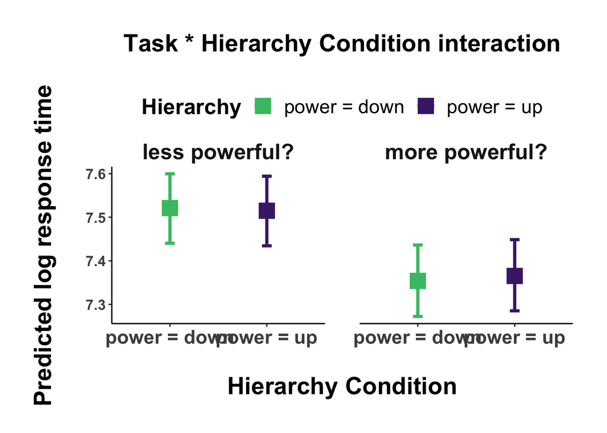

```r
p1 <- task_hierarchy %>%
  mutate(Hierarchy = ifelse(Hierarchy == 'BottomPower', 'power = down', 'power = up'),
         Task = ifelse(Task == 'powerful', 'more powerful?', 'less powerful?')) %>%
  ggplot(aes(x = Hierarchy, col = Hierarchy, y = estimate__))
p1 + geom_errorbar(aes(ymin = lower__, ymax = upper__), size = 1.25, width = 0.1) +
  geom_point(size = 6, pch = 15) +
  facet_wrap(~Task) +
  theme_bham_stats +
  labs(title = 'Task * Hierarchy Condition interaction\n') +
  ylab('Predicted log response time\n') +
  xlab('\nHierarchy Condition') +
  theme(plot.title = element_text(face = 'bold', size = 20, hjust = 0.5),
        axis.title = element_text(face = 'bold', size = 20),
        axis.text.x = element_text(face = 'bold', size = 16),
        axis.text.y = element_text(face = 'bold', size = 12),
        panel.grid.minor = element_blank(),
        panel.grid.major = element_blank(),
        legend.position = 'top') +
  scale_color_viridis_d(option = 'D', direction = -1, begin = 0.1, end = 0.7)
```

```r
ggsave('../figures/figure2.png', width = 10, height = 7)
```

Plot the subject / hierarchy / gender interaction:

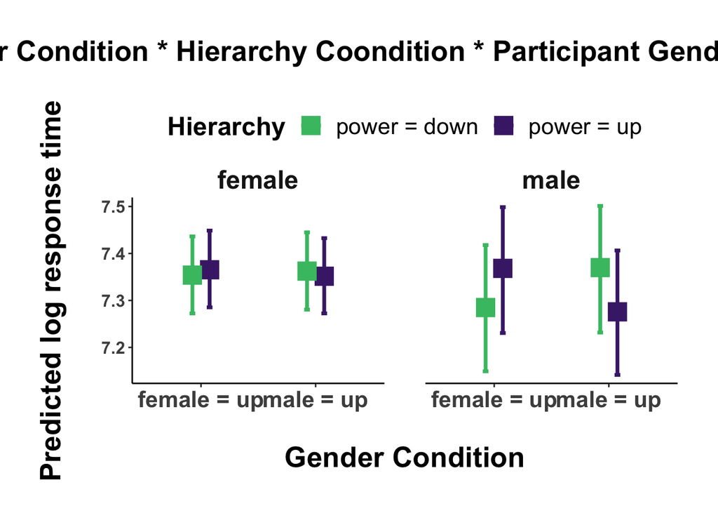

```r
p2 <- interaction_preds %>%
  mutate(Hierarchy = ifelse(Hierarchy == 'BottomPower', 'power = down', 'power = up'),
         Task = ifelse(Task == 'powerful', 'more powerful?', 'less powerful?'),
         Gender = ifelse(Gender == 'FemaleTop', 'female = up', 'male = up')) %>%
  ggplot(aes(x = Gender, col = Hierarchy, y = estimate__))
p2 + geom_errorbar(aes(ymin = lower__, ymax = upper__), size = 1.25, width = 0.1,
                   position = position_dodge(width = 0.3)) +
  geom_point(size = 6, pch = 15, position = position_dodge(width = 0.3)) +
  facet_wrap(~SubjGender) +
  theme_bham_stats +
  labs(title = 'Gender Condition * Hierarchy Coondition * Participant Gender interaction\n') +
  ylab('Predicted log response time\n') +
  xlab('\nGender Condition') +
  theme(plot.title = element_text(face = 'bold', size = 20, hjust = 0.5),
        axis.title = element_text(face = 'bold', size = 20),
        axis.text.x = element_text(face = 'bold', size = 16),
        axis.text.y = element_text(face = 'bold', size = 12),
        panel.grid.minor = element_blank(),
        panel.grid.major = element_blank(),
        legend.position = 'top') +
  scale_color_viridis_d(option = 'D', direction = -1, begin = 0.1, end = 0.7)
```

```r
ggsave('../figures/figure3.png', width = 10, height = 7)
```

## Extract the random effects coefficients for items:

Get the PairName df out this object with all the estimates:

```r
pairs <- coef(main_mdl)$PairName
pairs <- pairs[, 1, 1:11]
head(pairs)
```

```
##                     Intercept   Hierarchy1      Gender1 Hierarchy1:Gender1
## architector:builder  7.379955 -0.026660578 -0.003273272        -0.08697205
## bank_manger:clerk    7.477924 -0.008783044  0.006335227        -0.11301057
## boss:secretary       7.307893 -0.046402807  0.009743479        -0.12435782
## captain:sailor       7.400530 -0.009155207  0.021861809        -0.11615113
## chef:cook            7.312544 -0.011748954  0.017096207        -0.12000244
## coach:athlete        7.467146 -0.002312072  0.016267936        -0.09729564
##                     SubjGender1      Task1 SubjGender1:Hierarchy1
## architector:builder  -0.0340929 -0.1690379            -0.00728706
## bank_manger:clerk    -0.0340929 -0.1690379            -0.00728706
## boss:secretary       -0.0340929 -0.1690379            -0.00728706
## captain:sailor       -0.0340929 -0.1690379            -0.00728706
## chef:cook            -0.0340929 -0.1690379            -0.00728706
## coach:athlete        -0.0340929 -0.1690379            -0.00728706
##                     SubjGender1:Gender1 Task1:Hierarchy1 Task1:Gender1
## architector:builder       -0.0009970004       0.01802347   -0.02190932
## bank_manger:clerk         -0.0009970004       0.01802347   -0.02190932
## boss:secretary            -0.0009970004       0.01802347   -0.02190932
## captain:sailor            -0.0009970004       0.01802347   -0.02190932
## chef:cook                 -0.0009970004       0.01802347   -0.02190932
## coach:athlete             -0.0009970004       0.01802347   -0.02190932
##                     SubjGender1:Hierarchy1:Gender1
## architector:builder                     -0.1546569
## bank_manger:clerk                       -0.1546569
## boss:secretary                          -0.1546569
## captain:sailor                          -0.1546569
## chef:cook                               -0.1546569
## coach:athlete                           -0.1546569
```

Extract the relevant random effects estimates:

```r
gender_coefs <- pairs[, 'Gender1']
hierarchy_coefs <- pairs[, 'Hierarchy1']
gender_interact_coefs <- pairs[, 'Hierarchy1:Gender1']
gender_interact_coefs <- pairs[, 'Hierarchy1:Gender1']
```

Make them into tidy data frames:

```r
gender_coefs <- tibble(GenderCoef = gender_coefs,
                       Pair = names(gender_coefs))
hierarchy_coefs <- tibble(HierarchyCoef = hierarchy_coefs,
                          Pair = names(hierarchy_coefs))
interact_coefs <- tibble(InteractionCoef = gender_interact_coefs,
                         Pair = names(gender_interact_coefs))
```

Plot them. First the gender coefficients:

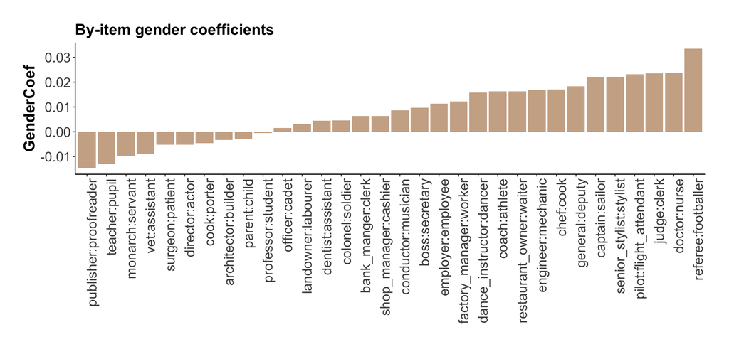

```r
gender_coefs %>% ggplot(aes(x = reorder(Pair, GenderCoef),
                            y = GenderCoef)) +
  geom_col(fill = 'peachpuff3') + theme_bham_stats +
  theme(axis.text.x = element_text(angle = 90, hjust = 1)) +
  labs(title = 'By-item gender coefficients') +
  xlab('')
```

Plot them. Next the hierarchy coefficients:

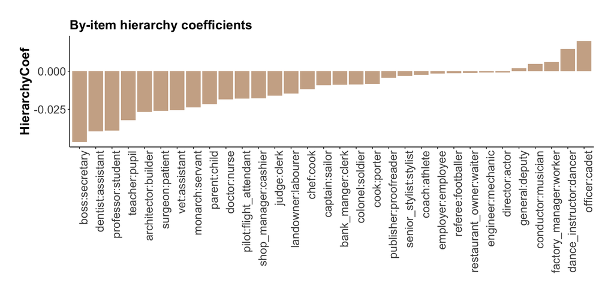

```r
hierarchy_coefs %>% ggplot(aes(x = reorder(Pair, HierarchyCoef),
                            y = HierarchyCoef)) +
  geom_col(fill = 'peachpuff3') + theme_bham_stats +
  theme(axis.text.x = element_text(angle = 90, hjust = 1)) +
  labs(title = 'By-item hierarchy coefficients') +
  xlab('')
```

Plot them. Next the hierarchy * gender interaction coefficients:

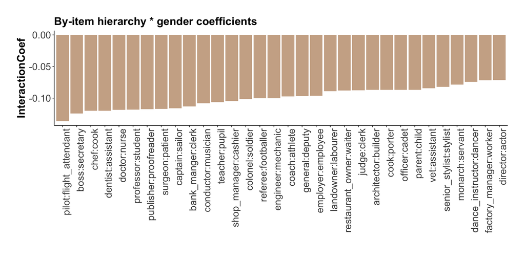

```r
interact_coefs %>% ggplot(aes(x = reorder(Pair, InteractionCoef),
                            y = InteractionCoef)) +
  geom_col(fill = 'peachpuff3') + theme_bham_stats +
  theme(axis.text.x = element_text(angle = 90, hjust = 1)) +
  labs(title = 'By-item hierarchy * gender coefficients') +
  xlab('')
```

## Merge this with corpus data

Load the corpus data:

```r
items <- read_csv('../data/item_corpus.csv')
```

Create the log-transformed ratio measure:

```r
items <- mutate(items,
                LogMF_Power = log10((PowerfulM + 1) / (PowerfulF + 1)),
                LogMF_Powerless = log10((PowerlessM + 1) / (PowerlessF + 1)),
                LogRatio = LogMF_Power / LogMF_Powerless)
```

Rename the pair clumn so that it matches the coefficient data frames:

```r
items <- rename(items,
                Pair = PairName)
```

Merge:

```r
gender_coefs <- left_join(gender_coefs, items)
hierarchy_coefs <- left_join(hierarchy_coefs, items)
interact_coefs <- left_join(interact_coefs, items)
```

## Correlations, ratio difference (M/F ratio of powerful - M/F ratio of powerless):

Look at correlations, with by-participant hierarchy slopes with the ratio difference score:

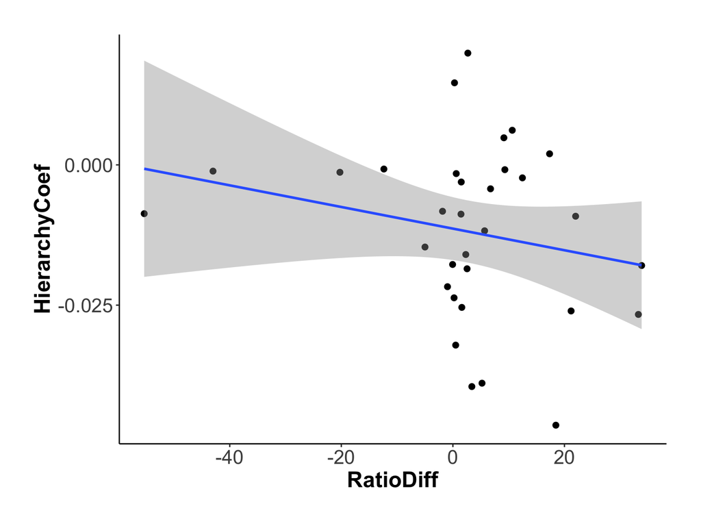

```r
hierarchy_coefs %>%
  ggplot(aes(x = RatioDiff,
                            y = HierarchyCoef)) +
  geom_point(size = 2) +
  geom_smooth(method = 'lm') +
  theme_bham_stats
```

Next, correlations with by-participant gender slopes:

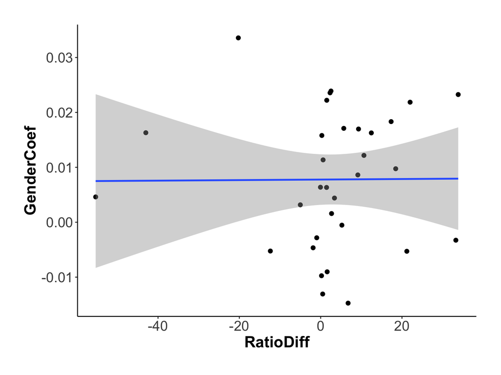

```r
gender_coefs %>%
  ggplot(aes(x = RatioDiff,
                            y = GenderCoef)) +
  geom_point(size = 2) +
  geom_smooth(method = 'lm') +
  theme_bham_stats
```

Finally, interaction:

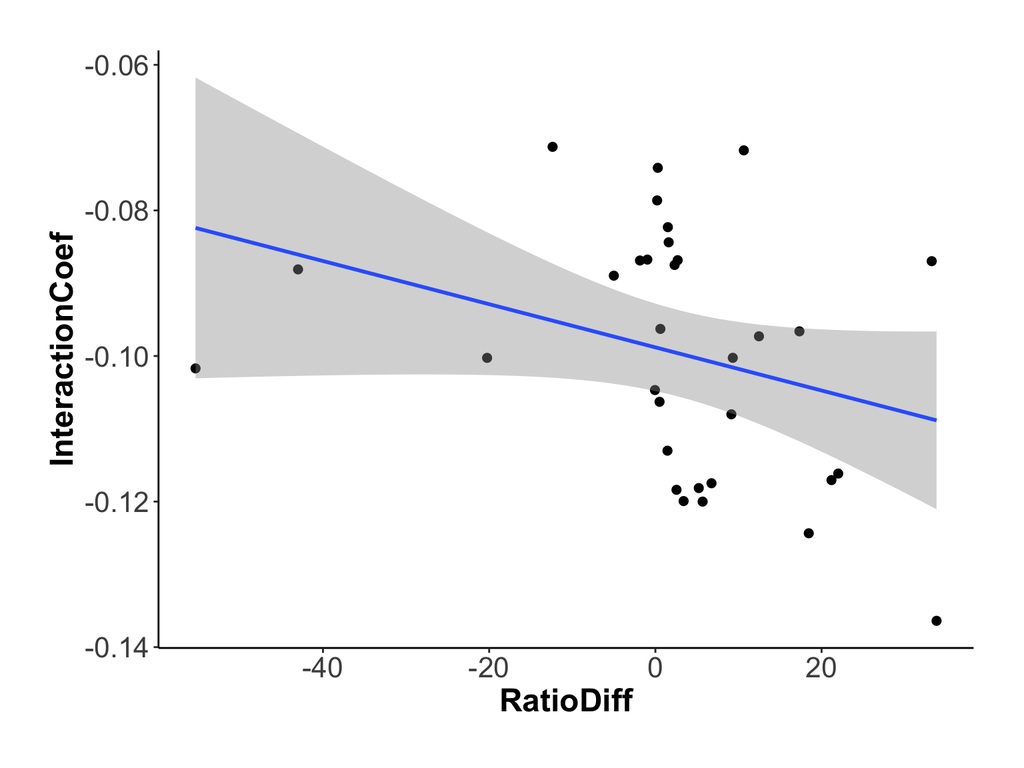

```r
interact_coefs %>%
  ggplot(aes(x = RatioDiff,
                            y = InteractionCoef)) +
  geom_point(size = 2) +
  geom_smooth(method = 'lm') +
  theme_bham_stats
```

Get the correlation coefficients for the ratio difference score:

```r
with(gender_coefs, cor(RatioDiff, GenderCoef))
```

```
## [1] 0.006998288
```

```r
with(hierarchy_coefs, cor(RatioDiff, HierarchyCoef))
```

```
## [1] -0.220178
```

```r
with(interact_coefs, cor(RatioDiff, InteractionCoef))
```

```
## [1] -0.3080195
```

## Correlations, ratio of ratis (M/F ratio of powerful / M/F ratio of powerless):

Look at correlations, with by-participant hierarchy slopes with the ratio of ratio score. Since there’s a really extreme ratio, for plotting purposes this is excluded:

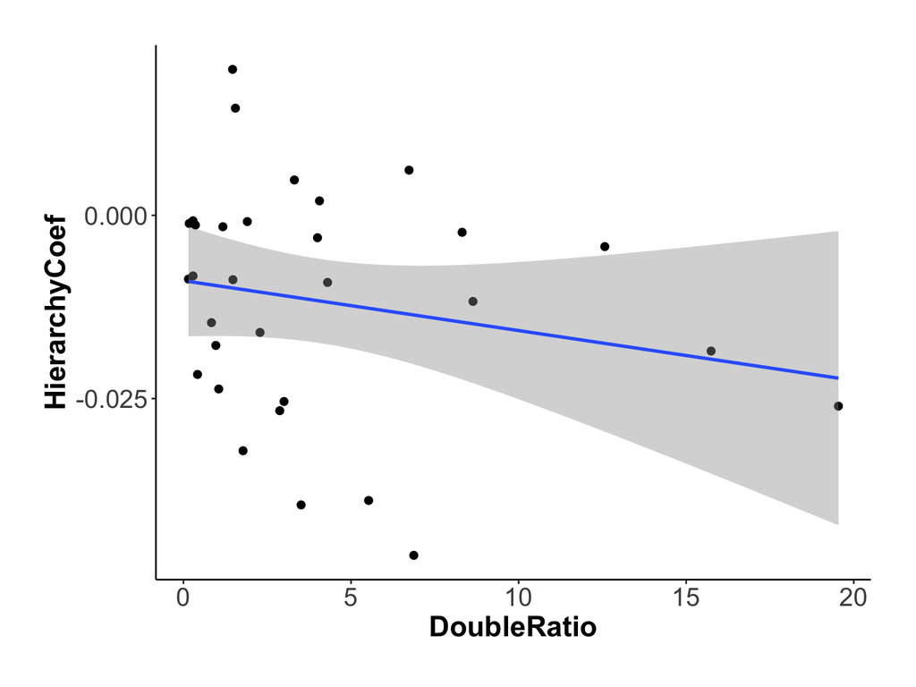

```r
hierarchy_coefs %>%
  filter(DoubleRatio < 200) %>%
  ggplot(aes(x = DoubleRatio,
                            y = HierarchyCoef)) +
  geom_point(size = 2) +
  geom_smooth(method = 'lm') +
  theme_bham_stats
```

Next, correlations with by-participant gender slopes:

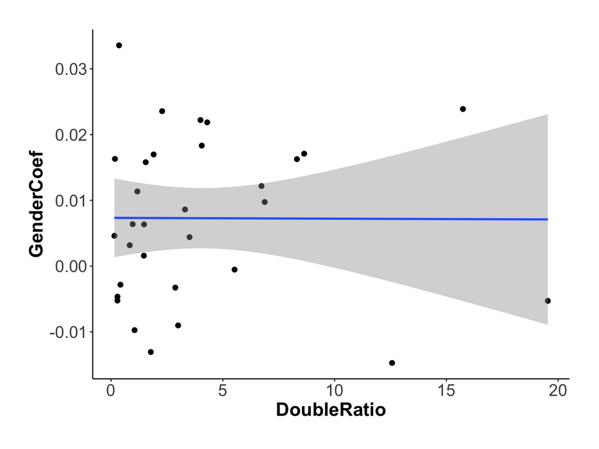

```r
gender_coefs %>%
  filter(DoubleRatio < 200) %>%
  ggplot(aes(x = DoubleRatio,
                            y = GenderCoef)) +
  geom_point(size = 2) +
  geom_smooth(method = 'lm') +
  theme_bham_stats
```

Finally, interaction, and make this a publication-ready plot:

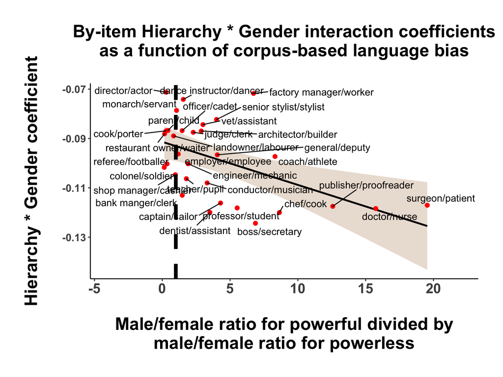

```r
interact_coefs %>%
  mutate(Pair = str_replace_all(Pair, '_', ' '),
         Pair = str_replace_all(Pair, ':', '/')) %>%
  filter(DoubleRatio < 200) %>%
  ggplot(aes(x = DoubleRatio,
                            y = InteractionCoef,
             label = Pair)) +
  coord_cartesian(xlim = c(-4, 22)) +
  geom_smooth(method = 'lm', col = 'black', fill = 'peachpuff3') +
  geom_point(col = 'red', size = 2) +
  geom_text_repel(size = 4, force = 11) +
  geom_vline(xintercept = 1, linetype = 2, size = 2) +
  theme_bham_stats +
  labs(title = 'By-item Hierarchy * Gender interaction coefficients\nas a function of corpus-based language bias\n') +
  ylab('Hierarchy * Gender coefficient\n') +
  xlab('\nMale/female ratio for powerful divided by\nmale/female ratio for powerless') +
  theme(plot.title = element_text(face = 'bold', size = 20, hjust = 0.5),
        axis.title = element_text(face = 'bold', size = 20),
        axis.text.x = element_text(face = 'bold', size = 16),
        axis.text.y = element_text(face = 'bold', size = 12),
        panel.grid.minor = element_blank(),
        panel.grid.major = element_blank())
```

```r
ggsave('../figures/figure4.png', width = 14, height = 8)
```

## Perform correlations with random slopes

Get the correlation coefficients for the ratio difference score. With the high-leverage point:

```r
with(gender_coefs, cor(DoubleRatio, GenderCoef))
```

```
## [1] 0.2252169
```

```r
with(hierarchy_coefs, cor(DoubleRatio, HierarchyCoef))
```

```
## [1] -0.09743799
```

```r
with(interact_coefs, cor(DoubleRatio, InteractionCoef))
```

```
## [1] -0.4528264
```

… without the high-leverage point:

```r
with(filter(gender_coefs, DoubleRatio < 200), cor(DoubleRatio, GenderCoef))
```

```
## [1] -0.004663662
```

```r
with(filter(hierarchy_coefs, DoubleRatio < 200), cor(DoubleRatio, HierarchyCoef))
```

```
## [1] -0.2040055
```

```r
with(filter(interact_coefs, DoubleRatio < 200), cor(DoubleRatio, InteractionCoef))
```

```
## [1] -0.5167762
```

## Estimate uncertainty in these correlations with Bayesian regression models:

Z-transform both predictor and response to make the regression model equal to a correlation. Also run this without the influential point (similar results are obtained if it’s included, as the correlations above show).

```r
gender_z <- gender_coefs %>%
  filter(DoubleRatio < 200) %>%
  mutate(Ratio_z = DoubleRatio - mean(DoubleRatio),
         Ratio_z = Ratio_z / sd(Ratio_z),
         Gender_z = GenderCoef - mean(GenderCoef),
         Gender_z = Gender_z / sd(Gender_z))

hierarchy_z <- hierarchy_coefs %>%
  filter(DoubleRatio < 200) %>%
  mutate(Ratio_z = DoubleRatio - mean(DoubleRatio),
         Ratio_z = Ratio_z / sd(Ratio_z),
         Hierarchy_z = HierarchyCoef - mean(HierarchyCoef),
         Hierarchy_z = Hierarchy_z / sd(Hierarchy_z))

interact_z <- interact_coefs %>%
  filter(DoubleRatio < 200) %>%
  mutate(Ratio_z = DoubleRatio - mean(DoubleRatio),
         Ratio_z = Ratio_z / sd(Ratio_z),
         Inter_z = InteractionCoef - mean(InteractionCoef),
         Inter_z = Inter_z / sd(Inter_z))
```

Set the prior:

```r
my_priors <- c(prior(normal(0, 0.5), class = b))
```

Run the Bayesian regressions for correlations (without intercept since everything’s centered):

```r
gender_brm <- brm(Gender_z ~ -1 + Ratio_z,
                  data = gender_z, prior = my_priors,
                  init = 0, seed = 42)
hierarchy_brm <- brm(Hierarchy_z ~ -1 + Ratio_z,
                  data = hierarchy_z, prior = my_priors,
                  init = 0, seed = 42)
```

```
## recompiling to avoid crashing R session
```

```r
interact_brm <- brm(Inter_z ~ -1 + Ratio_z,
                  data = interact_z, prior = my_priors,
                  init = 0, seed = 42)
```

```
## recompiling to avoid crashing R session
```

Look at the output:

```r
summary(gender_brm)
```

```
##  Family: gaussian
##   Links: mu = identity; sigma = identity
## Formula: Gender_z ~ -1 + Ratio_z
##    Data: gender_z (Number of observations: 31)
## Samples: 4 chains, each with iter = 2000; warmup = 1000; thin = 1;
##          total post-warmup samples = 4000
##
## Population-Level Effects:
##         Estimate Est.Error l-95% CI u-95% CI Eff.Sample Rhat
## Ratio_z    -0.00      0.18    -0.36     0.35       3639 1.00
##
## Family Specific Parameters:
##       Estimate Est.Error l-95% CI u-95% CI Eff.Sample Rhat
## sigma     1.04      0.14     0.81     1.34       3761 1.00
##
## Samples were drawn using sampling(NUTS). For each parameter, Eff.Sample
## is a crude measure of effective sample size, and Rhat is the potential
## scale reduction factor on split chains (at convergence, Rhat = 1).
```

```r
summary(hierarchy_brm)
```

```
##  Family: gaussian
##   Links: mu = identity; sigma = identity
## Formula: Hierarchy_z ~ -1 + Ratio_z
##    Data: hierarchy_z (Number of observations: 31)
## Samples: 4 chains, each with iter = 2000; warmup = 1000; thin = 1;
##          total post-warmup samples = 4000
##
## Population-Level Effects:
##         Estimate Est.Error l-95% CI u-95% CI Eff.Sample Rhat
## Ratio_z    -0.18      0.17    -0.52     0.16       3011 1.00
##
## Family Specific Parameters:
##       Estimate Est.Error l-95% CI u-95% CI Eff.Sample Rhat
## sigma     1.02      0.14     0.79     1.33       2369 1.00
##
## Samples were drawn using sampling(NUTS). For each parameter, Eff.Sample
## is a crude measure of effective sample size, and Rhat is the potential
## scale reduction factor on split chains (at convergence, Rhat = 1).
```

```r
summary(interact_brm)
```

```
##  Family: gaussian
##   Links: mu = identity; sigma = identity
## Formula: Inter_z ~ -1 + Ratio_z
##    Data: interact_z (Number of observations: 31)
## Samples: 4 chains, each with iter = 2000; warmup = 1000; thin = 1;
##          total post-warmup samples = 4000
##
## Population-Level Effects:
##         Estimate Est.Error l-95% CI u-95% CI Eff.Sample Rhat
## Ratio_z    -0.46      0.15    -0.77    -0.16       2729 1.00
##
## Family Specific Parameters:
##       Estimate Est.Error l-95% CI u-95% CI Eff.Sample Rhat
## sigma     0.89      0.12     0.69     1.16       2779 1.00
##
## Samples were drawn using sampling(NUTS). For each parameter, Eff.Sample
## is a crude measure of effective sample size, and Rhat is the potential
## scale reduction factor on split chains (at convergence, Rhat = 1).
```

Marginal effects:

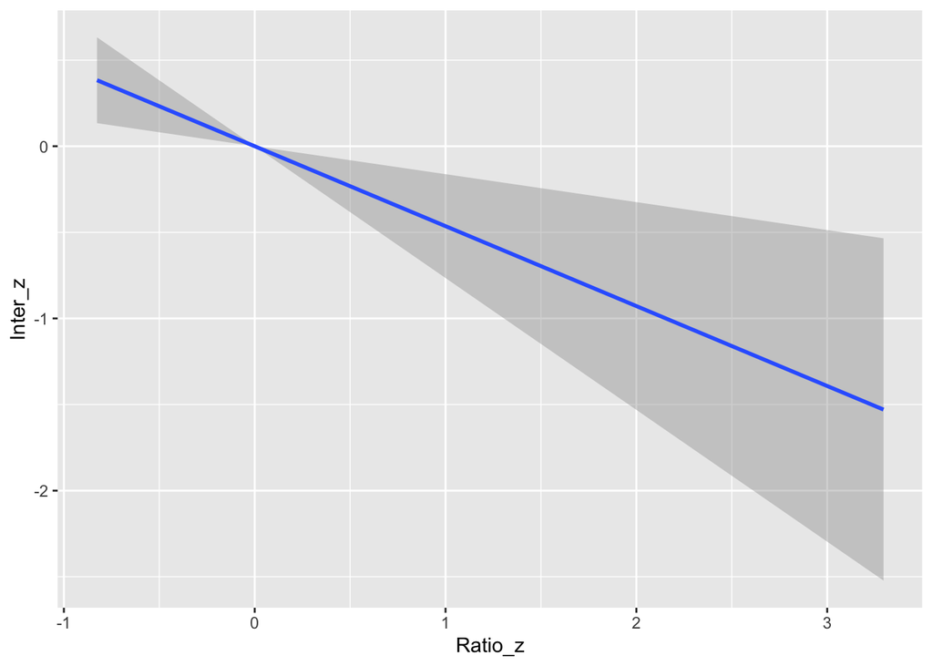

```r
marginal_effects(interact_brm, 'Ratio_z')
```

This completes this analysis.